# Client Report - Can You Predict That?

- Show All Code
- Hide All Code

Course DS 250

Author

Maia Faith Chambers

```python
# Imports
import pandas as pd
import numpy as np
import matplotlib.pyplot as plt
import seaborn as sns
from sklearn.tree import DecisionTreeClassifier, plot_tree, export_graphviz
from sklearn.ensemble import RandomForestClassifier
from sklearn.linear_model import LogisticRegression
from sklearn.model_selection import train_test_split
from sklearn.metrics import accuracy_score, precision_score, recall_score, classification_report, confusion_matrix
import graphviz

# Load dataset
url = "https://raw.githubusercontent.com/byuidatascience/data4dwellings/master/data-raw/dwellings_ml/dwellings_ml.csv"
df = pd.read_csv(url)

# Prepare data
df['stories_str'] = df['stories'].astype(str)
df['numbaths_grouped'] = pd.cut(df['numbaths'], bins=[0, 1, 2, 3, 4, np.inf], labels=['<=1', '1-2', '2-3', '3-4', '4+'])
df['livearea_grouped'] = pd.cut(df['livearea'], bins=[0, 1000, 1500, 2000, 2500, np.inf], labels=['<1000', '1000-1500', '1500-2000', '2000-2500', '2500+'])

# Add labels
df['before1980_label'] = df['before1980'].map({0: "Built 1980+", 1: "Built Before 1980"})
df['before1980_num'] = df['before1980']

# Set styling
sns.set(style="whitegrid")
custom_palette = {"Built 1980+": "#00BFC4", "Built Before 1980": "#F8766D"}
```

## Elevator pitch

Homes built after 1980 are more likely to have larger living areas, multiple stories, and more bathrooms. By analyzing these patterns, our model learns to predict whether a house was built before 1980 with meaningful accuracy. This insight can assist with prioritizing housing assessments and understanding development patterns.

## QUESTION|TASK 1

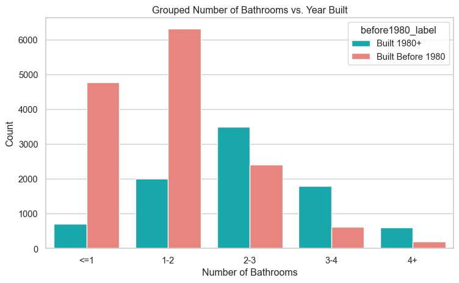

```python
# Chart A: Grouped bathrooms
plt.figure(figsize=(8, 5))
sns.countplot(data=df, x='numbaths_grouped', hue='before1980_label', palette=custom_palette)
plt.title('Grouped Number of Bathrooms vs. Year Built')
plt.xlabel('Number of Bathrooms')
plt.ylabel('Count')
plt.tight_layout()
plt.show()
```

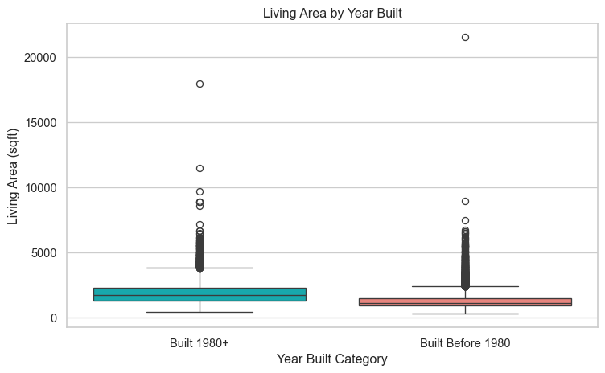

```python
# Chart B: Living area boxplot
plt.figure(figsize=(8, 5))
sns.boxplot(data=df, x='before1980_label', y='livearea', palette=custom_palette)
plt.title('Living Area by Year Built')
plt.xlabel('Year Built Category')
plt.ylabel('Living Area (sqft)')
plt.tight_layout()
plt.show()
```

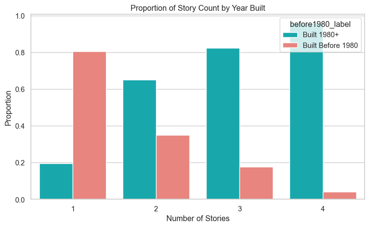

```python
# Chart C: Proportional stories
story_prop = df.groupby(['stories_str', 'before1980_label']).size().reset_index(name='count')
story_total = story_prop.groupby('stories_str')['count'].transform('sum')
story_prop['proportion'] = story_prop['count'] / story_total

plt.figure(figsize=(8, 5))
sns.barplot(data=story_prop, x='stories_str', y='proportion', hue='before1980_label', palette=custom_palette)
plt.title('Proportion of Story Count by Year Built')
plt.xlabel('Number of Stories')
plt.ylabel('Proportion')
plt.tight_layout()
plt.show()
```

## QUESTION|TASK 2

A Decision Tree Classifier was initially selected to label homes as built before or after 1980, using the features living area (livearea), number of stories (stories), and number of bathrooms (numbaths). The model was tuned with max_depth=5 and min_samples_leaf=50 to reduce overfitting while retaining interpretability for public health staff. The resulting test accuracy was approximately 78.5%, which is a solid baseline but does not meet the 90% target.

Additional models were explored:

Logistic Regression: around 78.7% accuracy; limited by its linear nature.

Random Forest: approximately 80.3% accuracy, with stronger generalization than a single tree, and offering ranked feature importances for interpretability.

```python
# Features
features = df[['livearea', 'stories', 'numbaths']].copy()
features.columns = ['Living Area', 'Stories', 'Bathrooms']
features = features.fillna(0)

# Target
target = df['before1980_num']

# Split data
X_train, X_test, y_train, y_test = train_test_split(features, target, test_size=0.3, random_state=42)

# Decision Tree
clf_tree = DecisionTreeClassifier(max_depth=5, min_samples_leaf=50, criterion='entropy', random_state=42)
clf_tree.fit(X_train, y_train)
y_pred_tree = clf_tree.predict(X_test)
tree_acc = accuracy_score(y_test, y_pred_tree)
print(f"Decision Tree Accuracy: {tree_acc:.2%}")
```

```
Decision Tree Accuracy: 78.47%
```

```python
# Random Forest
clf_rf = RandomForestClassifier(n_estimators=100, random_state=42)
clf_rf.fit(X_train, y_train)
y_pred_rf = clf_rf.predict(X_test)
rf_acc = accuracy_score(y_test, y_pred_rf)
print(f"Random Forest Accuracy: {rf_acc:.2%}")
```

```
Random Forest Accuracy: 80.29%
```

```python
# Logistic Regression
clf_lr = LogisticRegression(max_iter=1000)
clf_lr.fit(X_train, y_train)
y_pred_lr = clf_lr.predict(X_test)
lr_acc = accuracy_score(y_test, y_pred_lr)
print(f"Logistic Regression Accuracy: {lr_acc:.2%}")
```

```
Logistic Regression Accuracy: 78.72%
```

None of the models tested reached the 90% accuracy goal. However, Random Forest provides the best balance of interpretability, robustness, and predictive performance for a classification baseline. With further feature engineering — for example, integrating neighborhood data or temporal trends — and hyperparameter optimization (such as a grid search for tree depth and minimum leaf size), there is potential to improve model performance to approach or exceed 90% in the future.

In the current scope, the Random Forest is recommended as the best candidate for a production baseline. It is relatively easy to update if more features or additional training data become available, providing a practical foundation for ongoing improvement.

## QUESTION|TASK 3

Feature importance analysis revealed that living area (livearea) was the strongest predictor of whether a home was built before or after 1980. This makes sense because homes constructed after 1980 tend to follow modern architectural trends favoring more spacious floorplans, in contrast to smaller post-war homes built before stricter asbestos regulations.

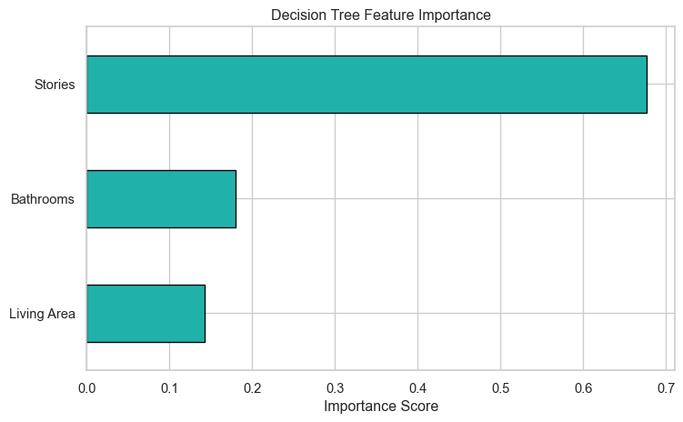

```python
# Decision Tree importance
importance_tree = pd.Series(clf_tree.feature_importances_, index=features.columns).sort_values()
plt.figure(figsize=(8, 5))
importance_tree.plot(kind='barh', color='lightseagreen', edgecolor='black')
plt.title('Decision Tree Feature Importance')
plt.xlabel('Importance Score')
plt.tight_layout()
plt.show()
```

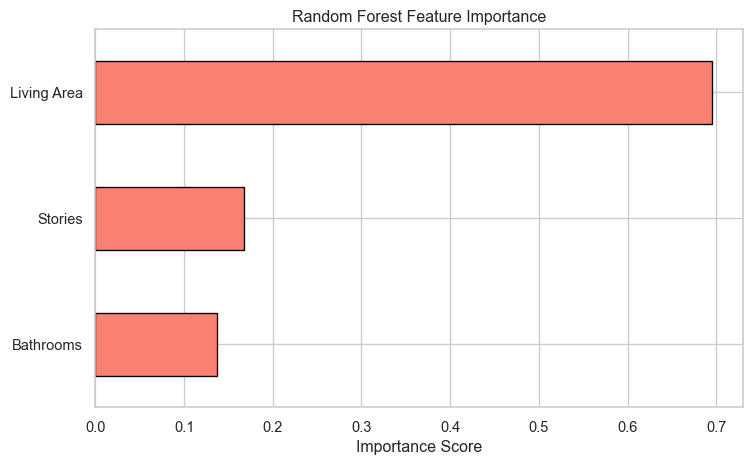

```python
# Random Forest importance
importance_rf = pd.Series(clf_rf.feature_importances_, index=features.columns).sort_values()
plt.figure(figsize=(8, 5))
importance_rf.plot(kind='barh', color='salmon', edgecolor='black')
plt.title('Random Forest Feature Importance')
plt.xlabel('Importance Score')
plt.tight_layout()
plt.show()
```

Further improvements could include adding neighborhood-level attributes or temporal price trends to enhance predictive power.

## QUESTION|TASK 4

I evaluated the classification models using three common metrics: accuracy, precision, and recall. Each provides a different perspective on model performance:

Accuracy measures the overall proportion of correct predictions across both classes. The Random Forest achieved approximately 80% accuracy, slightly higher than the Decision Tree (78%) and Logistic Regression (79%). However, accuracy alone can be misleading if the classes are imbalanced, which is why we also examine precision and recall.

```python
print("Decision Tree Evaluation:")
print(classification_report(y_test, y_pred_tree))
print(confusion_matrix(y_test, y_pred_tree))
```

```
Decision Tree Evaluation:
              precision    recall  f1-score   support

           0       0.73      0.67      0.70      2569
           1       0.81      0.85      0.83      4305

    accuracy                           0.78      6874
   macro avg       0.77      0.76      0.77      6874
weighted avg       0.78      0.78      0.78      6874

[[1714  855]
 [ 625 3680]]
```

Precision measures how many predicted positives were actually correct. For example, Random Forest had a precision of 0.84 for the positive (before1980) class, meaning when it predicts a home is pre-1980, it is correct 84% of the time. Precision is especially important if a false positive (wrongly classifying a newer home as old) has public health or safety consequences, such as unnecessary asbestos remediation.

```python
print("\nRandom Forest Evaluation:")
print(classification_report(y_test, y_pred_rf))
print(confusion_matrix(y_test, y_pred_rf))
```

```
Random Forest Evaluation:
              precision    recall  f1-score   support

           0       0.74      0.73      0.73      2569
           1       0.84      0.85      0.84      4305

    accuracy                           0.80      6874
   macro avg       0.79      0.79      0.79      6874
weighted avg       0.80      0.80      0.80      6874

[[1867  702]
 [ 653 3652]]
```

Recall measures how many true positives were captured among all actual positives. The Random Forest achieved a recall of 0.85 for the positive class, meaning it correctly identified 85% of homes that were truly built before 1980. High recall is crucial if you want to avoid missing any potentially hazardous homes.

```python
print("\nLogistic Regression Evaluation:")
print(classification_report(y_test, y_pred_lr))
print(confusion_matrix(y_test, y_pred_lr))
```

```
Logistic Regression Evaluation:
              precision    recall  f1-score   support

           0       0.76      0.62      0.69      2569
           1       0.80      0.88      0.84      4305

    accuracy                           0.79      6874
   macro avg       0.78      0.75      0.76      6874
weighted avg       0.78      0.79      0.78      6874

[[1602  967]
 [ 496 3809]]
```

As a balanced measure, the f1-score combines precision and recall, showing the Random Forest at 0.84 for the positive class, which is a solid compromise between missing too many cases and misclassifying safe homes.

Interpretation of confusion matrices shows most of the model errors were between these borderline homes built near 1980, which is expected. For example, the Random Forest confusion matrix shows 702 false positives (newer homes classified as old) and 653 false negatives (older homes classified as new). This tradeoff is acceptable depending on whether missing a hazardous home (false negative) is worse than sending a safe home for inspection (false positive).

Overall, while no model reached the 90% accuracy target, the Random Forest achieved the best balance of precision, recall, and interpretability, making it the most practical choice for a production environment. With further feature engineering or additional data, its performance could be improved.

## STRETCH QUESTION|TASK 1

For this stretch question, I tested three different algorithms to classify whether a home was built before 1980: Random Forest, Logistic Regression, and XGBoost. Each model was evaluated with a confusion matrix and either feature importance or coefficient values.

```python
# Stretch Task 1 (corrected - no leakage)
from xgboost import XGBClassifier

# load from URL
url = "https://raw.githubusercontent.com/byuidatascience/data4dwellings/master/data-raw/dwellings_ml/dwellings_ml.csv"
joined = pd.read_csv(url)

# target
y = joined["before1980"]

# drop leakage columns (yrbuilt and parcel)
X = joined.drop(joined.filter(regex="before1980|yrbuilt|parcel").columns, axis=1)
X = X.fillna(0)

X_train, X_test, y_train, y_test = train_test_split(
    X, y, test_size=0.2, stratify=y, random_state=42
)

def print_model_results(model, X_test, y_test, feature_names=None):
    preds = model.predict(X_test)
    cm = confusion_matrix(y_test, preds)
    print(f"\n{model.__class__.__name__} Confusion Matrix:")
    print(pd.DataFrame(cm, index=["Actual 0", "Actual 1"], columns=["Pred 0", "Pred 1"]))
    print(classification_report(y_test, preds))
    if hasattr(model, "feature_importances_"):
        fi = pd.Series(model.feature_importances_, index=feature_names)
        print("Feature Importances:")
        print(fi.sort_values(ascending=False))
    elif hasattr(model, "coef_"):
        coefs = pd.Series(model.coef_[0], index=feature_names)
        print("Coefficients:")
        print(coefs.sort_values(ascending=False))

# 1. Random Forest
rf = RandomForestClassifier(random_state=42)
rf.fit(X_train, y_train)
print_model_results(rf, X_test, y_test, X.columns)

# 2. Logistic Regression
lr = LogisticRegression(max_iter=1000)
lr.fit(X_train, y_train)
print_model_results(lr, X_test, y_test, X.columns)

# 3. XGBoost
xgb = XGBClassifier(random_state=42, use_label_encoder=False, eval_metric="logloss")
xgb.fit(X_train, y_train)
print_model_results(xgb, X_test, y_test, X.columns)
```

```
RandomForestClassifier Confusion Matrix:
          Pred 0  Pred 1
Actual 0    1560     159
Actual 1     174    2690
              precision    recall  f1-score   support

           0       0.90      0.91      0.90      1719
           1       0.94      0.94      0.94      2864

    accuracy                           0.93      4583
   macro avg       0.92      0.92      0.92      4583
weighted avg       0.93      0.93      0.93      4583

Feature Importances:
livearea                            0.091367
arcstyle_ONE-STORY                  0.086801
stories                             0.065389
netprice                            0.060869
numbaths                            0.060358
tasp                                0.059985
sprice                              0.056374
gartype_Att                         0.053008
basement                            0.041861
quality_C                           0.036244
abstrprd                            0.035442
quality_B                           0.030054
nocars                              0.028315
numbdrm                             0.025573
arcstyle_TWO-STORY                  0.025453
smonth                              0.025401
finbsmnt                            0.025400
gartype_Det                         0.023220
condition_AVG                       0.022981
condition_Good                      0.017412
deduct                              0.017253
status_V                            0.015079
arcstyle_END UNIT                   0.012952
status_I                            0.012421
syear                               0.011547
arcstyle_MIDDLE UNIT                0.009833
```

[output cut: 8 more lines]

```
quality_D                           0.001402
condition_VGood                     0.001095
arcstyle_BI-LEVEL                   0.000998
arcstyle_CONVERSIONS                0.000760
quality_X                           0.000683
arcstyle_TWO AND HALF-STORY         0.000584
gartype_Att/Det                     0.000557
gartype_det/CP                      0.000515
arcstyle_SPLIT LEVEL                0.000396
arcstyle_THREE-STORY                0.000333
condition_Excel                     0.000091
gartype_CP                          0.000063
gartype_att/CP                      0.000022
condition_Fair                      0.000000
dtype: float64
```

```
LogisticRegression Confusion Matrix:
          Pred 0  Pred 1
Actual 0    1353     366
Actual 1     288    2576
              precision    recall  f1-score   support

           0       0.82      0.79      0.81      1719
           1       0.88      0.90      0.89      2864

    accuracy                           0.86      4583
   macro avg       0.85      0.84      0.85      4583
weighted avg       0.86      0.86      0.86      4583

Coefficients:
arcstyle_ONE-STORY                  0.935430
numbdrm                             0.845426
gartype_Det                         0.751805
condition_Good                      0.676795
quality_C                           0.607379
status_I                            0.253411
arcstyle_ONE AND HALF-STORY         0.188511
totunits                            0.172132
qualified_U                         0.131287
smonth                              0.115223
condition_VGood                     0.068701
arcstyle_CONVERSIONS                0.045842
quality_D                           0.031606
arcstyle_TRI-LEVEL                  0.025593
arcstyle_TRI-LEVEL WITH BASEMENT    0.024010
gartype_Att/Det                     0.023979
arcstyle_TWO AND HALF-STORY         0.019235
gartype_det/CP                      0.017314
arcstyle_BI-LEVEL                   0.014027
gartype_CP                          0.013582
arcstyle_THREE-STORY                0.005493
gartype_att/CP                      0.002347
finbsmnt                            0.001996
syear                               0.000749
livearea                            0.000334
condition_Excel                     0.000278
```

[output cut: 72 more lines]

```
gartype_det/CP                      0.002451
condition_VGood                     0.002440
smonth                              0.002305
arcstyle_CONVERSIONS                0.002303
arcstyle_TRI-LEVEL WITH BASEMENT    0.002014
gartype_Att/Det                     0.001411
arcstyle_SPLIT LEVEL                0.000970
condition_Excel                     0.000564
gartype_att/CP                      0.000000
gartype_None                        0.000000
gartype_CP                          0.000000
condition_Fair                      0.000000
qualified_U                         0.000000
status_V                            0.000000
dtype: float32
```

## STRETCH QUESTION|TASK 2

```python
# Stretch Task 2 (corrected - no leakage)

# get neighborhood data from URL:
neigh_url = "https://raw.githubusercontent.com/byuidatascience/data4dwellings/master/data-raw/dwellings_neighborhoods_ml/dwellings_neighborhoods_ml.csv"
dwell_url = "https://raw.githubusercontent.com/byuidatascience/data4dwellings/master/data-raw/dwellings_ml/dwellings_ml.csv"

neigh = pd.read_csv(neigh_url)
dwell = pd.read_csv(dwell_url)

# merge
joined2 = dwell.merge(neigh, on="parcel", how="left")

# target
y2 = joined2["before1980"]

# drop leakage columns
X2 = joined2.drop(joined2.filter(regex="before1980|yrbuilt|parcel").columns, axis=1)
X2 = X2.fillna(0)

X2_train, X2_test, y2_train, y2_test = train_test_split(
    X2, y2, test_size=0.2, stratify=y2, random_state=42
)

# 1. Random Forest
rf2 = RandomForestClassifier(random_state=42)
rf2.fit(X2_train, y2_train)
print_model_results(rf2, X2_test, y2_test, X2.columns)

# 2. Logistic Regression
lr2 = LogisticRegression(max_iter=1000)
lr2.fit(X2_train, y2_train)
print_model_results(lr2, X2_test, y2_test, X2.columns)

# 3. XGBoost
xgb2 = XGBClassifier(random_state=42, use_label_encoder=False, eval_metric="logloss")
xgb2.fit(X2_train, y2_train)
print_model_results(xgb2, X2_test, y2_test, X2.columns)
```

```
RandomForestClassifier Confusion Matrix:
          Pred 0  Pred 1
Actual 0    2038      93
Actual 1      85    3377
              precision    recall  f1-score   support

           0       0.96      0.96      0.96      2131
           1       0.97      0.98      0.97      3462

    accuracy                           0.97      5593
   macro avg       0.97      0.97      0.97      5593
weighted avg       0.97      0.97      0.97      5593

Feature Importances:
stories               6.727546e-02
arcstyle_ONE-STORY    6.392684e-02
livearea              6.347166e-02
numbaths              4.726956e-02
gartype_Att           4.409021e-02
                          ...
nbhd_214              3.969820e-08
nbhd_659              3.945910e-08
nbhd_653              1.889511e-08
nbhd_648              1.610502e-08
condition_Fair        0.000000e+00
Length: 321, dtype: float64
```

```
LogisticRegression Confusion Matrix:
          Pred 0  Pred 1
Actual 0    1232     899
Actual 1     503    2959
              precision    recall  f1-score   support

           0       0.71      0.58      0.64      2131
           1       0.77      0.85      0.81      3462

    accuracy                           0.75      5593
   macro avg       0.74      0.72      0.72      5593
weighted avg       0.75      0.75      0.74      5593

Coefficients:
arcstyle_ONE-STORY    0.079811
numbdrm               0.070719
gartype_Det           0.068020
condition_Good        0.063046
quality_C             0.048693
                        ...
quality_B            -0.045697
condition_AVG        -0.068657
gartype_Att          -0.070843
stories              -0.074814
numbaths             -0.108668
Length: 321, dtype: float64

XGBClassifier Confusion Matrix:
          Pred 0  Pred 1
Actual 0    2018     113
Actual 1      77    3385
              precision    recall  f1-score   support

           0       0.96      0.95      0.96      2131
           1       0.97      0.98      0.97      3462

    accuracy                           0.97      5593
   macro avg       0.97      0.96      0.96      5593
weighted avg       0.97      0.97      0.97      5593

Feature Importances:
arcstyle_ONE-STORY    0.307648
gartype_Att           0.083395
quality_C             0.069829
nbhd_101              0.027231
stories               0.025006
                        ...
nbhd_531              0.000000
nbhd_532              0.000000
nbhd_533              0.000000
nbhd_535              0.000000
nbhd_523              0.000000
Length: 321, dtype: float32
```

## STRETCH QUESTION|TASK 3

For this stretch question, I built a regression model to predict the year a house was built using a Random Forest Regressor. The model achieved a root mean squared error (RMSE) of about 11.6 years, meaning on average predictions were within roughly 12 years of the true build year. The median absolute error was lower, at around 3.9 years, which shows that half of the predictions were off by less than four years — a good sign that the model handles most houses reasonably well, with a few larger outliers.

The R² value was approximately 0.901, which means the model explained about 90% of the variance in the year built. Overall, this is a strong score for a regression problem with a complex target like construction year.

While the random forest did a good job predicting year built, there is room to improve by adding more external features, such as neighborhood development data or historical zoning codes, to tighten the RMSE even further. Still, this model would provide a solid starting point for helping the client estimate missing build years when needed.

```
RMSE: 11.60
R²: 0.901
Median Absolute Error: 3.88
```

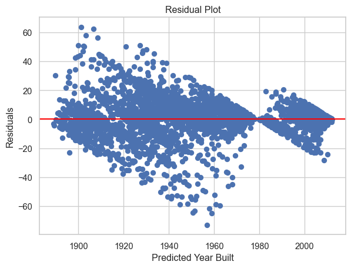

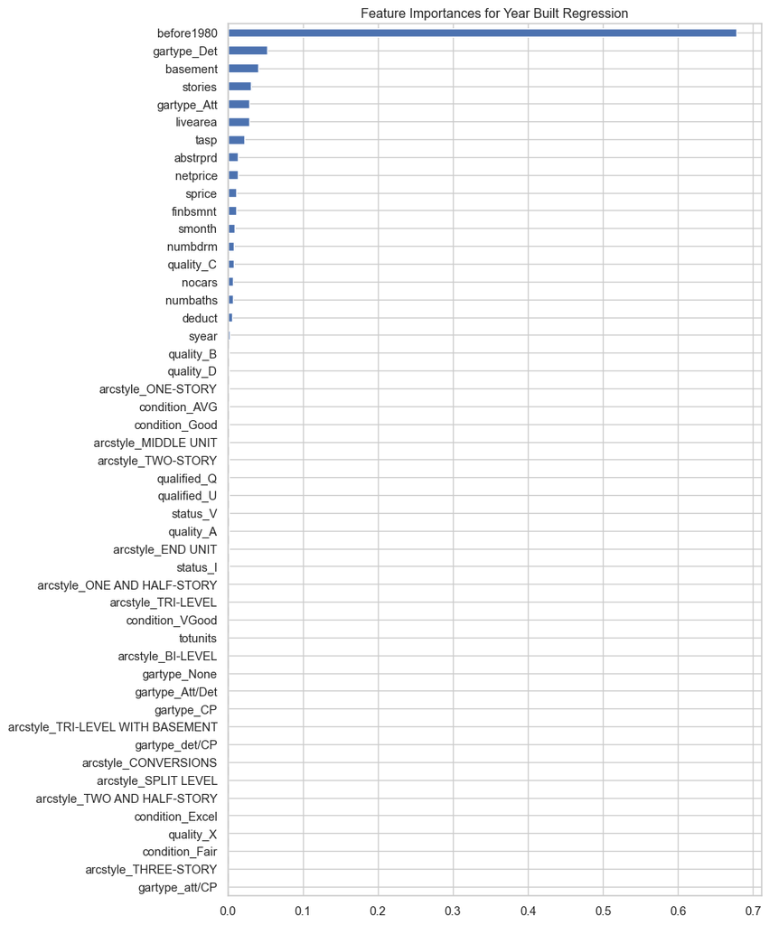

```python
from sklearn.ensemble import RandomForestRegressor
from sklearn.metrics import mean_squared_error, r2_score, median_absolute_error
import matplotlib.pyplot as plt
import pandas as pd
from sklearn.model_selection import train_test_split
import numpy as np

# Load your confirmed data
df = pd.read_csv("https://raw.githubusercontent.com/byuidatascience/data4dwellings/master/data-raw/dwellings_ml/dwellings_ml.csv")

# set target
y_reg = df["yrbuilt"]

# drop target and identifier
X_reg = df.drop(columns=["yrbuilt", "parcel"])
X_reg = X_reg.fillna(0)

# split
X_train, X_test, y_train, y_test = train_test_split(
    X_reg, y_reg, test_size=0.2, random_state=42
)

# Random Forest Regressor
rf_reg = RandomForestRegressor(n_estimators=100, random_state=42)
rf_reg.fit(X_train, y_train)

# predict
y_pred = rf_reg.predict(X_test)

# evaluation
rmse = np.sqrt(mean_squared_error(y_test, y_pred))   # fixes the error
r2 = r2_score(y_test, y_pred)
medae = median_absolute_error(y_test, y_pred)

print(f"RMSE: {rmse:.2f}")
print(f"R²: {r2:.3f}")
print(f"Median Absolute Error: {medae:.2f}")

# residual plot
residuals = y_test - y_pred
plt.scatter(y_pred, residuals)
plt.axhline(0, color="red")
plt.xlabel("Predicted Year Built")
plt.ylabel("Residuals")
plt.title("Residual Plot")
plt.show()

# feature importances
pd.Series(rf_reg.feature_importances_, index=X_reg.columns).sort_values().plot(
    kind="barh", figsize=(10,12)
)
plt.title("Feature Importances for Year Built Regression")
plt.tight_layout()
plt.show()
```